# Predicting Taxi Fares with Random Forests

Utkarsh Sharma

08/10/2019

## 1. 49999 New York taxi trips

To drive a yellow New York taxi, you have to hold a “medallion” from the city’s *Taxi and Limousine Commission*. Recently, one of those changed hands for over one million dollars, which shows how lucrative the job can be. But this is the age of business intelligence and analytics! Even taxi drivers can stand to benefit from some careful investigation of the data, guiding them to maximize their profits. In this project, we will analyze a random sample of 49999 New York journeys made in 2013. We will also use regression trees and random forests to build a model that can predict the locations and times when the biggest fares can be earned. Let’s start by taking a look at the data!

```r
# Loading the tidyverse
library(tidyverse)

# Reading in the taxi data
taxi <- read_csv('dataset/taxi.csv')

# Taking a look at the first couple of rows in taxi
head(taxi)
```

```
## # A tibble: 6 x 7
##   medallion pickup_datetime     pickup_longitude pickup_latitude
##   <chr>     <dttm>                         <dbl>           <dbl>
## 1 4D24F4D8… 2013-01-13 10:23:00            -73.9            40.8
## 2 A49C37EB… 2013-01-13 04:52:00            -74.0            40.7
## 3 1E4B72A8… 2013-01-13 10:47:00            -74.0            40.8
## 4 F7E4E943… 2013-01-13 11:14:00            -74.0            40.7
## 5 A9DC75D5… 2013-01-13 11:24:00            -74.0            40.8
## 6 19BF1BB5… 2013-01-13 10:51:00            -74.0            40.8
## # … with 3 more variables: trip_time_in_secs <dbl>, fare_amount <dbl>,
## #   tip_amount <dbl>
```

## 2. Cleaning the taxi data

As we can see above, the `taxi` dataset contains the times and price of a large number of taxi trips. Importantly we also get to know the location, the longitude and latitude, where the trip was started.

The `taxi` dataset needs a bit of polishing before we’re ready to use it.

```r
# Renaming the location variables,
#dropping any journeys with zero fares and zero tips,
# and creating the total variable as the log sum of fare and tip
taxi <- taxi %>%
        rename(long = pickup_longitude, lat = pickup_latitude) %>%
        filter(fare_amount > 0 | tip_amount > 0) %>%
        mutate(total = log(fare_amount + tip_amount))
```

## 3. Zooming in on Manhattan

While the dataset contains taxi trips from all over New York City, the bulk of the trips are to and from Manhattan, so let’s focus only on trips initiated there.

```r
# Reducing the data to taxi trips starting in Manhattan
taxi <- taxi  %>%
    filter(between(lat, 40.70, 40.83),
           between(long, -74.025, -73.93))
```

## 4. Where does the journey begin?

It’s time to draw a map! We’re going to use the excellent `ggmap` package together with `ggplot2` to visualize where in Manhattan people tend to start their taxi journeys.

D. Kahle and H. Wickham. ggmap: Spatial Visualization with ggplot2. The R Journal, 5(1), 144-161. URL http://journal.r-project.org/archive/2013-1/kahle-wickham.pdf

[figure not shown]

```r
# Loading in ggmap and viridis for nice colors
library(ggmap)
library(viridis)

# Retrieving a stored map object
manhattan <- readRDS("dataset/manhattan.rds")

# Drawing a density map with the number of journey start locations
ggmap(manhattan, darken = 0.5) +
  scale_fill_viridis(option = 'plasma') +
   geom_bin2d(data = taxi, aes(long, lat), bins = 60, alpha = 0.6) +
  labs(x = 'Longitutde', y = 'Latitude', fill = 'Journey')
```

## 5. Predicting taxi fares using a tree

The map showed that the journeys are highly concentrated in the business and tourist areas.

We’re now going to use a regression tree to predict the `total` fare with `lat` and `long` being the predictors. The `tree` algorithm will try to find cutpoints in those predictors that results in the decision tree with the best predictive capability.

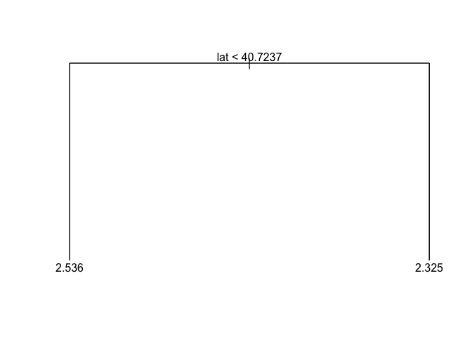

```r
# Loading in the rpart package
library(tree)

# Fitting a tree to lat and long
fitted_tree <- tree(formula = total ~ lat + long,
                    data = taxi)

# Draw a diagram of the tree structure
plot(fitted_tree)
text(fitted_tree)
```

## 6. It’s time. More predictors.

The tree above looks a bit frugal, it only includes one split: It predicts that trips where `lat < 40.7237` are more expensive, which makes sense as it is downtown Manhattan. But that’s it. It didn’t even include `long` as `tree` deemed that it didn’t improve the predictions. Taxi drivers will need more information than this and any driver paying for your data-driven insights would be disappointed with that.

Let’s start by adding some more predictors related to the *time* the taxi trip was made.

```r
# Loading in the lubridate package
library(lubridate)

# Generate the three new time variables
taxi <- taxi %>%
    mutate(hour = hour(pickup_datetime),
           wday = wday(pickup_datetime, label = TRUE),
           month = month(pickup_datetime, label = TRUE))

head(taxi)
```

```
## # A tibble: 6 x 11
##   medallion pickup_datetime      long   lat trip_time_in_se… fare_amount
##   <chr>     <dttm>              <dbl> <dbl>            <dbl>       <dbl>
## 1 4D24F4D8… 2013-01-13 10:23:00 -73.9  40.8              600         8
## 2 A49C37EB… 2013-01-13 04:52:00 -74.0  40.7              840        18
## 3 1E4B72A8… 2013-01-13 10:47:00 -74.0  40.8               60         3.5
## 4 F7E4E943… 2013-01-13 11:14:00 -74.0  40.7              720        11.5
## 5 A9DC75D5… 2013-01-13 11:24:00 -74.0  40.8              240         6.5
## 6 19BF1BB5… 2013-01-13 10:51:00 -74.0  40.8              540         8.5
## # … with 5 more variables: tip_amount <dbl>, total <dbl>, hour <int>,
## #   wday <ord>, month <ord>
```